# 6-analyze_cml_effect

CML effect: comparison with PBS data

**Need to run first:**

- `../0-prepare_data`
- `1-run_dge_analysis`
- `2-previsualize_data`
- `3-analyze_microbiota_effect_given_ages_sexes`

**Table of content**

1. Prepare data
2. Differential expression analysis
3. Z-scores of CML vs PBS DEGs in non CML / PBS samples
4. Volcano plots for SPF vs GF highlighting DEG in CML vs PBS

*Generated from a Jupyter Notebook - [Sources](https://github.com/bebatut/neuromac_GF_mices/blob/master/src/full/6-analyze_cml_effect.ipynb)*

# Load

```r
source("../load_libraries.R")
```

```
Allowing multi-threading with up to 4 threads.
```

```r
source("../functions.R")
```

Load the gene length

```r
gene_length = read.csv("../../data/gene_length.tabular", sep="\t", h = F) %>%
    rename('length' = 'V2') %>%
    rename('gene' = 'V1')
```

Load the count table

```r
counts = read.csv("../../data/cml_pbs_counts.tabular", sep="\t") %>%
    rename('gene' = 'X.KEY')
```

```r
dp = "../../results/dge/full/"
dir_path = paste(dp, "6-analyze_cml_effect/", sep='')
dir.create(dir_path, showWarnings = FALSE)
```

# Prepare data

Rename columns due to confusion in labelling of FastQ files

```r
counts = counts %>%
    rename('CML-1' = 'PBS_3') %>%
    rename('CML-2' = 'PBS_4') %>%
    rename('CML-3' = 'CML_2') %>%
    rename('CML-4' = 'PBS_1') %>%
    rename('PBS-1' = 'PBS_2') %>%
    rename('PBS-2' = 'CML_4') %>%
    rename('PBS-3' = 'CML_3') %>%
    rename('PBS-4' = 'CML_1') %>%
    select(c('gene', 'CML-1', 'CML-2', 'CML-3', 'CML-4', 'PBS-1', 'PBS-2', 'PBS-3', 'PBS-4'))
```

```r
counts
```

A data.frame: 24421 × 9

| gene <chr> | CML-1 <int> | CML-2 <int> | CML-3 <int> | CML-4 <int> | PBS-1 <int> | PBS-2 <int> | PBS-3 <int> | PBS-4 <int> |
| --- | --- | --- | --- | --- | --- | --- | --- | --- |
| 0610005C13Rik | 4 | 3 | 2 | 3 | 2 | 2 | 12 | 9 |
| 0610007P14Rik | 843 | 599 | 726 | 711 | 529 | 524 | 703 | 676 |
| 0610009B22Rik | 1252 | 786 | 966 | 894 | 946 | 1014 | 1254 | 1066 |
| 0610009L18Rik | 58 | 49 | 70 | 67 | 42 | 62 | 23 | 40 |
| 0610009O20Rik | 228 | 306 | 375 | 257 | 271 | 371 | 428 | 377 |
| 0610010B08Rik | 0 | 0 | 0 | 0 | 0 | 0 | 0 | 0 |
| 0610010F05Rik | 367 | 566 | 453 | 477 | 551 | 432 | 798 | 562 |
| 0610010K14Rik | 1382 | 1382 | 1185 | 1369 | 1356 | 1507 | 1362 | 1459 |
| 0610011F06Rik | 188 | 130 | 215 | 148 | 153 | 98 | 168 | 152 |
| 0610012G03Rik | 586 | 636 | 651 | 641 | 608 | 666 | 871 | 768 |
| 0610030E20Rik | 1164 | 1165 | 1201 | 1180 | 1191 | 1128 | 1268 | 1133 |
| 0610031O16Rik | 0 | 0 | 0 | 0 | 0 | 0 | 0 | 0 |
| 0610037L13Rik | 564 | 579 | 586 | 705 | 390 | 598 | 568 | 544 |
| 0610038B21Rik | 0 | 3 | 6 | 0 | 0 | 4 | 1 | 1 |
| 0610039H22Rik | 2 | 3 | 0 | 0 | 1 | 0 | 0 | 1 |
| 0610039K10Rik | 51 | 38 | 33 | 31 | 22 | 21 | 46 | 31 |
| 0610040B10Rik | 40 | 13 | 19 | 10 | 7 | 5 | 6 | 9 |
| 0610040F04Rik | 0 | 0 | 0 | 0 | 0 | 0 | 0 | 0 |
| 0610040J01Rik | 5352 | 5708 | 5966 | 5346 | 5582 | 5571 | 8139 | 6793 |
| 0610043K17Rik | 0 | 6 | 5 | 1 | 5 | 6 | 0 | 3 |
| 1010001N08Rik | 0 | 0 | 0 | 0 | 0 | 0 | 0 | 0 |
| 1110001J03Rik | 90 | 103 | 115 | 103 | 139 | 120 | 138 | 145 |
| 1110002L01Rik | 60 | 77 | 69 | 55 | 75 | 73 | 86 | 79 |
| 1110004E09Rik | 241 | 182 | 168 | 177 | 227 | 110 | 213 | 227 |
| 1110004F10Rik | 2185 | 1857 | 1781 | 1893 | 1725 | 1889 | 2212 | 2033 |
| 1110006O24Rik | 35 | 45 | 32 | 37 | 20 | 25 | 39 | 38 |
| 1110007C09Rik | 657 | 709 | 718 | 581 | 653 | 653 | 752 | 781 |
| 1110008F13Rik | 922 | 907 | 958 | 932 | 884 | 863 | 1157 | 1116 |
| 1110008L16Rik | 299 | 408 | 289 | 276 | 342 | 316 | 371 | 340 |
| 1110008P14Rik | 46 | 23 | 59 | 23 | 94 | 26 | 75 | 66 |
| ⋮ | ⋮ | ⋮ | ⋮ | ⋮ | ⋮ | ⋮ | ⋮ | ⋮ |
| Zscan26 | 519 | 433 | 473 | 368 | 440 | 457 | 551 | 478 |
| Zscan29 | 1147 | 1203 | 932 | 930 | 1134 | 891 | 2298 | 1469 |
| Zscan4a | 0 | 0 | 0 | 0 | 0 | 0 | 0 | 0 |
| Zscan4b | 0 | 0 | 0 | 0 | 0 | 0 | 0 | 0 |
| Zscan4c | 0 | 0 | 0 | 0 | 0 | 0 | 0 | 0 |
| Zscan4d | 0 | 0 | 0 | 0 | 0 | 0 | 0 | 0 |
| Zscan4f | 0 | 0 | 0 | 0 | 0 | 0 | 0 | 0 |
| Zscan5b | 0 | 0 | 0 | 0 | 0 | 0 | 0 | 0 |
| Zswim1 | 409 | 505 | 706 | 539 | 612 | 477 | 781 | 578 |
| Zswim2 | 0 | 0 | 0 | 0 | 0 | 0 | 0 | 0 |
| Zswim3 | 362 | 441 | 350 | 351 | 239 | 360 | 401 | 344 |
| Zswim4 | 386 | 527 | 448 | 345 | 413 | 496 | 670 | 603 |
| Zswim5 | 176 | 102 | 265 | 263 | 372 | 329 | 361 | 310 |
| Zswim6 | 1102 | 1051 | 1186 | 983 | 810 | 1296 | 1677 | 1154 |
| Zswim7 | 192 | 122 | 77 | 60 | 65 | 51 | 90 | 84 |
| Zswim8 | 259 | 360 | 325 | 308 | 319 | 215 | 429 | 320 |
| Zufsp | 1227 | 1429 | 1037 | 1008 | 912 | 1295 | 1219 | 1156 |
| Zw10 | 467 | 651 | 423 | 538 | 453 | 578 | 1127 | 780 |
| Zwilch | 41 | 0 | 37 | 0 | 0 | 11 | 15 | 8 |
| Zwint | 1522 | 1585 | 1366 | 1290 | 1414 | 1383 | 2122 | 1735 |
| Zxda | 257 | 234 | 321 | 387 | 292 | 361 | 463 | 315 |
| Zxdb | 301 | 322 | 265 | 304 | 285 | 125 | 415 | 296 |
| Zxdc | 804 | 960 | 1083 | 912 | 600 | 1090 | 1466 | 1084 |
| Zyg11a | 0 | 0 | 0 | 0 | 0 | 0 | 0 | 0 |
| Zyg11b | 2472 | 2702 | 2077 | 1349 | 2148 | 2633 | 3073 | 2497 |
| Zyx | 2027 | 2577 | 2115 | 2404 | 2546 | 2570 | 2774 | 2706 |
| Zzef1 | 514 | 549 | 594 | 448 | 645 | 776 | 828 | 648 |
| Zzz3 | 922 | 868 | 850 | 762 | 572 | 1140 | 1294 | 931 |
| a | 0 | 2 | 0 | 1 | 0 | 0 | 0 | 1 |
| l7Rn6 | 664 | 558 | 591 | 536 | 731 | 632 | 626 | 705 |

## Check data

```r
head(counts)
```

A data.frame: 6 × 9

|  | gene <chr> | CML-1 <int> | CML-2 <int> | CML-3 <int> | CML-4 <int> | PBS-1 <int> | PBS-2 <int> | PBS-3 <int> | PBS-4 <int> |
| --- | --- | --- | --- | --- | --- | --- | --- | --- | --- |
| 1 | 0610005C13Rik | 4 | 3 | 2 | 3 | 2 | 2 | 12 | 9 |
| 2 | 0610007P14Rik | 843 | 599 | 726 | 711 | 529 | 524 | 703 | 676 |
| 3 | 0610009B22Rik | 1252 | 786 | 966 | 894 | 946 | 1014 | 1254 | 1066 |
| 4 | 0610009L18Rik | 58 | 49 | 70 | 67 | 42 | 62 | 23 | 40 |
| 5 | 0610009O20Rik | 228 | 306 | 375 | 257 | 271 | 371 | 428 | 377 |
| 6 | 0610010B08Rik | 0 | 0 | 0 | 0 | 0 | 0 | 0 | 0 |

Percentage of gene names in count file that are in gene length file

```r
100 * sum(counts$gene %in% gene_length$gene)/length(counts$gene)
```

100

Percentage of gene names in ene length file that are in count file

```r
100 * sum(gene_length$gene %in% counts$gene)/length(gene_length$gene)
```

100

## Remove spurious data

Remove the rows with only zeros (printed: before / after)

```r
dim(counts)
```

1. 24421

2. 9

```r
counts = counts %>%
    mutate(sumVar = rowSums(.[2:9])) %>%
    filter(sumVar > 1) %>%
    select(-sumVar)
```

```r
dim(counts)
```

1. 15305

2. 9

## Check and clean genes names

Rename the genes to be sure there is a map with Entrez Gene Identifers:

```r
cml_counts = counts
```

```r
# Extract mapping new names
load("../../results/dge/prepared_counts.RData")
prepared_counts = counts %>%
    rownames_to_column('gene')
original_counts = read.csv("../../data/counts.tabular", sep="\t") %>%
    rename('gene' = 'Gene') %>%
    select(names(prepared_counts)) %>%
    mutate(sumVar = rowSums(.[2:62])) %>%
    filter(sumVar > 1) %>%
    select(-sumVar)
in_orig_not_in_prep_counts = dplyr::setdiff(original_counts, prepared_counts)
in_prep_not_in_orig_counts = dplyr::setdiff(prepared_counts, original_counts)
if(identical(in_orig_not_in_prep_counts$"GF_104w_F_1_2", in_prep_not_in_orig_counts$"GF_104w_F_1_2")){
    new_names = dplyr::tibble(gene = in_orig_not_in_prep_counts$gene, new = in_prep_not_in_orig_counts$gene)}
head(new_names)
```

A tibble: 6 × 2

| gene <chr> | new <chr> |
| --- | --- |
| 0610011F06Rik | Mettl26 |
| 1110001J03Rik | Fmc1 |
| 1110007C09Rik | Card19 |
| 1190002F15Rik | Lockd |
| 1200014J11Rik | Ncbp3 |
| 1500012F01Rik | Zfas1 |

```r
rename_genes = function(table, mapping, col_to_check){
    tmp_table = dplyr::full_join(table, mapping, by = "gene") %>%
        filter(!is.na(.[,col_to_check]))
    correct_name_table = tmp_table %>%
        filter(is.na(new)) %>%
        select(-new)
    to_correct_name_table = tmp_table %>%
        filter(!is.na(new)) %>%
        select(-gene) %>%
        rename(gene = new)
    return(dplyr::union(correct_name_table, to_correct_name_table))
}
```

```r
# Apply the mapping to rename genes on count table
counts = rename_genes(cml_counts, new_names, 2)
dim(counts)
```

1. 15305

2. 9

```r
# Apply the mapping to rename genes on gene length table
# and filter to keep the same names as in count table
gene_length = rename_genes(gene_length, new_names, 2) %>%
    filter(gene %in% counts$gene)
dim(gene_length)
```

1. 15305

2. 2

## Create metadata

Extract the description of the samples

```r
samples_names = names(counts %>% select(-gene))
metadata = as_tibble(t(sapply(sapply(samples_names, strsplit, split = "-"), unlist))) %>%
    mutate(sample = samples_names) %>%
    rename(treatment = V1) %>%
    rename(replicate = V2)
metadata
```

A tibble: 8 × 3

| treatment <chr> | replicate <chr> | sample <chr> |
| --- | --- | --- |
| CML | 1 | CML-1 |
| CML | 2 | CML-2 |
| CML | 3 | CML-3 |
| CML | 4 | CML-4 |
| PBS | 1 | PBS-1 |
| PBS | 2 | PBS-2 |
| PBS | 3 | PBS-3 |
| PBS | 4 | PBS-4 |

# Differential expression analysis

```r
count_mat = as.matrix(counts %>% select(-gene))
rownames(count_mat) = counts$gene
head(count_mat)
```

A matrix: 6 × 8 of type int

|  | CML-1 | CML-2 | CML-3 | CML-4 | PBS-1 | PBS-2 | PBS-3 | PBS-4 |
| --- | --- | --- | --- | --- | --- | --- | --- | --- |
| 0610005C13Rik | 4 | 3 | 2 | 3 | 2 | 2 | 12 | 9 |
| 0610007P14Rik | 843 | 599 | 726 | 711 | 529 | 524 | 703 | 676 |
| 0610009B22Rik | 1252 | 786 | 966 | 894 | 946 | 1014 | 1254 | 1066 |
| 0610009L18Rik | 58 | 49 | 70 | 67 | 42 | 62 | 23 | 40 |
| 0610009O20Rik | 228 | 306 | 375 | 257 | 271 | 371 | 428 | 377 |
| 0610010F05Rik | 367 | 566 | 453 | 477 | 551 | 432 | 798 | 562 |

Construct DESeqDataSet

```r
dds = DESeqDataSetFromMatrix(
        countData = count_mat,
        colData = metadata,
        design = ~ treatment)
```

```r
# organize levels of the factor (PBS being the reference)
dds$treatment = relevel(dds$treatment, ref="PBS")
```

## Testing how the complexification of the model explain the data

% genes with significant LRT adjusted p-value for the model with treatment as factor compared to a model without any factors

```r
dge = DESeq(dds, test="LRT", reduced = ~ 1)
LRT_res = results(dge, alpha=0.05)
nb = get_sign_padj(LRT_res)
100*nb/dim(LRT_res)[1]
```

0.222149624305782

## Exploratory analysis and visualization

We use here the variance stabilizing transformation

```r
vsd = vst(dds, blind = FALSE)
```

Distances between the samples

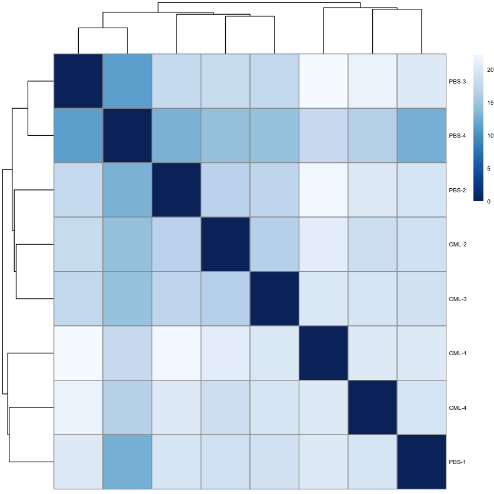

```r
sampleDists = dist(t(assay(vsd)))
sampleDistMatrix = as.matrix( sampleDists )
colnames(sampleDistMatrix) = NULL
colors = colorRampPalette( rev(brewer.pal(9, "Blues")) )(255)
pheatmap(sampleDistMatrix,
         clustering_distance_rows = sampleDists,
         clustering_distance_cols = sampleDists,
         col = colors,
         fontsize = 6)
```

PCA plot

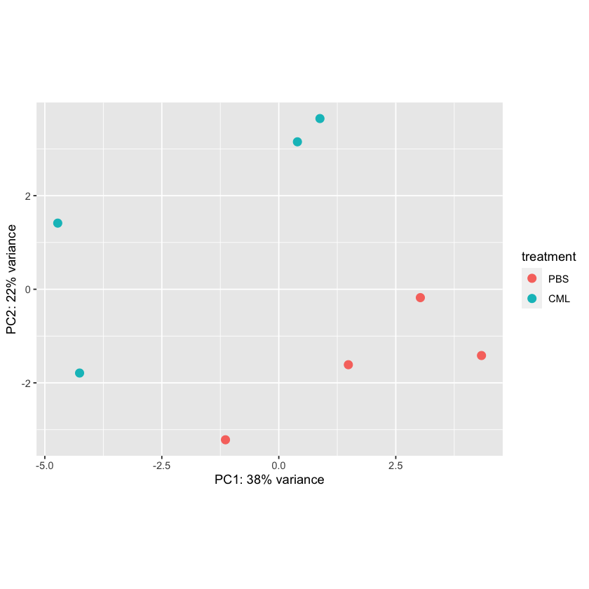

```r
pcaData = plotPCA(vsd, intgroup = c("treatment"), returnData = TRUE)
percentVar = round(100 * attr(pcaData, "percentVar"))
ggplot(pcaData, aes(x = PC1, y = PC2, color = treatment)) +
  geom_point(size =3) +
  xlab(paste0("PC1: ", percentVar[1], "% variance")) +
  ylab(paste0("PC2: ", percentVar[2], "% variance")) +
  coord_fixed()
```

## Differential expression analysis

```r
dge = DESeq(dds)
```

Extract the normalized counts

```r
norm_counts = counts(dge, normalized = TRUE)
```

## Extraction of the differentially expressed genes

```r
sign_adj_pvalue = 0.05
```

Extract results

```r
res = results(dge, alpha=0.05, test="Wald")
deg_results = as.data.frame(res) %>%
        rownames_to_column('gene')
```

```r
norm_counts = as.data.frame(norm_counts) %>%
    rownames_to_column('gene')
```

### DEG with abs(FC) > 1.5

```r
sign_fc = 1.5
deg1 = deg_results %>%
    filter(padj < sign_adj_pvalue & abs(log2FoldChange) >= log2(sign_fc))
```

Genes with significant p-values and abs(FC) > 1.5

```r
deg1$gene
```

1. '2810013P06Rik'

2. '4833419F23Rik'

3. 'A430033K04Rik'

4. 'AI854703'

5. 'Atad2'

6. 'C4b'

7. 'Ccl22'

8. 'Cenpe'

9. 'Cers4'

10. 'Chic1'

11. 'Chil3'

12. 'F630028O10Rik'

13. 'Fos'

14. 'Gbp6'

15. 'Glb1l'

16. 'Gm5420'

17. 'Hsph1'

18. 'Igf2bp2'

19. 'Ipo4'

20. 'Itpr3'

21. 'Kcna7'

22. 'Ltf'

23. 'Maob'

24. 'N4bp3'

25. 'Nek5'

26. 'Ngp'

27. 'Pglyrp1'

28. 'Rora'

29. 'S100a8'

30. 'S100a9'

31. 'Scai'

32. 'Sema3c'

33. 'Setx'

34. 'Sh2d5'

35. 'She'

36. 'Snap91'

37. 'Snhg17'

38. 'Tle6'

39. 'Ttc37'

40. 'Vat1l'

41. 'Wdr5b'

42. 'Zfp414'

43. 'Zkscan2'

```r
length(deg1$gene)
```

43

```r
deg1 = deg1 %>%
    left_join(norm_counts, by='gene') %>%
    select(-c(baseMean, lfcSE, stat, pvalue))
```

```r
deg1 %>% write.table(file = paste(dir_path, 'high_fc_deg.csv'), sep="\t", quote=F, row.names=F)
```

```r
deg1 %>%
    left_join(norm_counts, by='gene')
```

A data.frame: 43 × 19

| gene <chr> | log2FoldChange <dbl> | padj <dbl> | CML-1.x <dbl> | CML-2.x <dbl> | CML-3.x <dbl> | CML-4.x <dbl> | PBS-1.x <dbl> | PBS-2.x <dbl> | PBS-3.x <dbl> | PBS-4.x <dbl> | CML-1.y <dbl> | CML-2.y <dbl> | CML-3.y <dbl> | CML-4.y <dbl> | PBS-1.y <dbl> | PBS-2.y <dbl> | PBS-3.y <dbl> | PBS-4.y <dbl> |
| --- | --- | --- | --- | --- | --- | --- | --- | --- | --- | --- | --- | --- | --- | --- | --- | --- | --- | --- |
| 2810013P06Rik | 0.7895123 | 3.850348e-02 | 1017.184367 | 559.331505 | 941.472284 | 845.253627 | 358.434481 | 567.150127 | 548.252218 | 470.7612415 | 1017.184367 | 559.331505 | 941.472284 | 845.253627 | 358.434481 | 567.150127 | 548.252218 | 470.7612415 |
| 4833419F23Rik | 4.1105653 | 1.905729e-02 | 11.336401 | 50.196417 | 31.914315 | 14.401438 | 0.000000 | 2.040108 | 3.088745 | 0.8983993 | 11.336401 | 50.196417 | 31.914315 | 14.401438 | 0.000000 | 2.040108 | 3.088745 | 0.8983993 |
| A430033K04Rik | 0.6319824 | 2.728739e-02 | 556.514243 | 547.038505 | 629.775810 | 665.789554 | 472.874406 | 340.698098 | 393.814974 | 341.3917400 | 556.514243 | 547.038505 | 629.775810 | 665.789554 | 472.874406 | 340.698098 | 393.814974 | 341.3917400 |
| AI854703 | -6.2457069 | 7.883005e-03 | 1.030582 | 0.000000 | 0.000000 | 0.000000 | 28.070170 | 44.882384 | 3.860931 | 20.6631843 | 1.030582 | 0.000000 | 0.000000 | 0.000000 | 28.070170 | 44.882384 | 3.860931 | 20.6631843 |
| Atad2 | -0.9471494 | 4.649729e-02 | 207.146968 | 174.150835 | 388.290829 | 196.081117 | 503.103820 | 416.182108 | 529.719749 | 412.3652860 | 207.146968 | 174.150835 | 388.290829 | 196.081117 | 503.103820 | 416.182108 | 529.719749 | 412.3652860 |
| C4b | -2.1075094 | 7.050800e-07 | 94.813538 | 150.589251 | 121.274396 | 58.713555 | 328.205067 | 348.858532 | 738.982215 | 416.8572826 | 94.813538 | 150.589251 | 121.274396 | 58.713555 | 328.205067 | 348.858532 | 738.982215 | 416.8572826 |
| Ccl22 | -3.3443467 | 3.882241e-02 | 8.244655 | 22.537167 | 3.191431 | 0.000000 | 23.751682 | 216.251487 | 40.153684 | 66.4815494 | 8.244655 | 22.537167 | 3.191431 | 0.000000 | 23.751682 | 216.251487 | 40.153684 | 66.4815494 |
| Cenpe | -5.9649110 | 1.105178e-02 | 0.000000 | 0.000000 | 1.063810 | 0.000000 | 10.796219 | 39.782113 | 11.582793 | 17.9679863 | 0.000000 | 0.000000 | 1.063810 | 0.000000 | 10.796219 | 39.782113 | 11.582793 | 17.9679863 |
| Cers4 | 1.6496472 | 9.173821e-03 | 91.721792 | 134.198584 | 93.615323 | 85.300825 | 19.433195 | 46.922493 | 28.570890 | 34.1391740 | 91.721792 | 134.198584 | 93.615323 | 85.300825 | 19.433195 | 46.922493 | 28.570890 | 34.1391740 |
| Chic1 | 5.0092216 | 7.497557e-03 | 71.110153 | 13.317417 | 6.382863 | 99.702263 | 0.000000 | 0.000000 | 4.633117 | 0.8983993 | 71.110153 | 13.317417 | 6.382863 | 99.702263 | 0.000000 | 0.000000 | 4.633117 | 0.8983993 |
| Chil3 | 9.7334149 | 1.582415e-02 | 116.455758 | 413.864337 | 435.098490 | 0.000000 | 0.000000 | 1.020054 | 0.000000 | 0.0000000 | 116.455758 | 413.864337 | 435.098490 | 0.000000 | 0.000000 | 1.020054 | 0.000000 | 0.0000000 |
| F630028O10Rik | 6.1687966 | 4.731508e-02 | 3.091746 | 10.244167 | 8.510484 | 27.695073 | 0.000000 | 0.000000 | 0.000000 | 0.0000000 | 3.091746 | 10.244167 | 8.510484 | 27.695073 | 0.000000 | 0.000000 | 0.000000 | 0.0000000 |
| Fos | 0.9804601 | 3.916334e-02 | 450.364304 | 333.959836 | 687.221576 | 393.270036 | 174.898753 | 225.431975 | 315.051979 | 228.1934262 | 450.364304 | 333.959836 | 687.221576 | 393.270036 | 174.898753 | 225.431975 | 315.051979 | 228.1934262 |
| Gbp6 | -5.9728458 | 1.582415e-02 | 0.000000 | 1.024417 | 0.000000 | 0.000000 | 6.477732 | 40.802167 | 22.393400 | 10.7807918 | 0.000000 | 1.024417 | 0.000000 | 0.000000 | 6.477732 | 40.802167 | 22.393400 | 10.7807918 |
| Glb1l | -1.2517686 | 4.136577e-02 | 127.792160 | 74.782417 | 135.103932 | 44.312117 | 245.074178 | 199.930620 | 226.250563 | 238.9742180 | 127.792160 | 74.782417 | 135.103932 | 44.312117 | 245.074178 | 199.930620 | 226.250563 | 238.9742180 |
| Gm5420 | 2.7892598 | 9.196835e-03 | 64.926662 | 33.805750 | 35.105746 | 40.988708 | 7.557354 | 3.060163 | 3.088745 | 11.6791911 | 64.926662 | 33.805750 | 35.105746 | 40.988708 | 7.557354 | 3.060163 | 3.088745 | 11.6791911 |
| Hsph1 | -1.0536145 | 2.433166e-03 | 570.942390 | 914.804091 | 914.877021 | 543.931233 | 1473.683936 | 1064.936570 | 2104.979643 | 1467.0860829 | 570.942390 | 914.804091 | 914.877021 | 543.931233 | 1473.683936 | 1064.936570 | 2104.979643 | 1467.0860829 |
| Igf2bp2 | 0.9943598 | 4.623902e-02 | 419.446846 | 346.252836 | 294.675506 | 306.861408 | 115.519547 | 265.214088 | 150.576313 | 155.4230817 | 419.446846 | 346.252836 | 294.675506 | 306.861408 | 115.519547 | 265.214088 | 150.576313 | 155.4230817 |
| Ipo4 | -0.6588971 | 1.036555e-02 | 494.679327 | 594.161672 | 604.244358 | 692.376824 | 792.442497 | 1136.340363 | 944.383750 | 892.1105207 | 494.679327 | 594.161672 | 604.244358 | 692.376824 | 792.442497 | 1136.340363 | 944.383750 | 892.1105207 |
| Itpr3 | -1.4114863 | 4.739175e-03 | 111.302849 | 67.611501 | 68.083871 | 49.851131 | 142.510095 | 221.351758 | 236.288984 | 189.5622557 | 111.302849 | 67.611501 | 68.083871 | 49.851131 | 142.510095 | 221.351758 | 236.288984 | 189.5622557 |
| Kcna7 | -4.9706310 | 3.647965e-02 | 2.061164 | 1.024417 | 0.000000 | 0.000000 | 35.627524 | 43.862330 | 3.860931 | 15.2727884 | 2.061164 | 1.024417 | 0.000000 | 0.000000 | 35.627524 | 43.862330 | 3.860931 | 15.2727884 |
| Ltf | 10.7709230 | 4.617099e-02 | 257.645483 | 589.039588 | 355.312704 | 0.000000 | 0.000000 | 0.000000 | 0.000000 | 0.0000000 | 257.645483 | 589.039588 | 355.312704 | 0.000000 | 0.000000 | 0.000000 | 0.000000 | 0.0000000 |
| Maob | -6.8860800 | 9.936175e-04 | 0.000000 | 0.000000 | 0.000000 | 0.000000 | 36.707146 | 17.340921 | 14.671538 | 23.3583822 | 0.000000 | 0.000000 | 0.000000 | 0.000000 | 36.707146 | 17.340921 | 14.671538 | 23.3583822 |
| N4bp3 | -4.0208412 | 2.704050e-02 | 2.061164 | 4.097667 | 0.000000 | 0.000000 | 20.512817 | 17.340921 | 29.343076 | 34.1391740 | 2.061164 | 4.097667 | 0.000000 | 0.000000 | 20.512817 | 17.340921 | 29.343076 | 34.1391740 |
| Nek5 | -3.9313311 | 8.700386e-03 | 7.214074 | 0.000000 | 3.191431 | 0.000000 | 62.618072 | 36.721951 | 24.709959 | 35.9359726 | 7.214074 | 0.000000 | 3.191431 | 0.000000 | 62.618072 | 36.721951 | 24.709959 | 35.9359726 |
| Ngp | 9.9691827 | 3.186159e-03 | 443.150231 | 1318.424261 | 1148.915329 | 0.000000 | 0.000000 | 2.040108 | 0.000000 | 0.8983993 | 443.150231 | 1318.424261 | 1148.915329 | 0.000000 | 0.000000 | 2.040108 | 0.000000 | 0.8983993 |
| Pglyrp1 | 6.9037463 | 2.719199e-02 | 11.336401 | 34.830167 | 36.169557 | 0.000000 | 0.000000 | 0.000000 | 0.000000 | 0.0000000 | 11.336401 | 34.830167 | 36.169557 | 0.000000 | 0.000000 | 0.000000 | 0.000000 | 0.0000000 |
| Rora | 0.7249272 | 3.574620e-02 | 304.021670 | 305.276169 | 390.418450 | 422.072912 | 208.367033 | 200.950675 | 238.605543 | 211.1238392 | 304.021670 | 305.276169 | 390.418450 | 422.072912 | 208.367033 | 200.950675 | 238.605543 | 211.1238392 |
| S100a8 | 12.0335434 | 2.679847e-02 | 504.985147 | 1207.787260 | 1171.255349 | 0.000000 | 0.000000 | 0.000000 | 0.000000 | 0.0000000 | 504.985147 | 1207.787260 | 1171.255349 | 0.000000 | 0.000000 | 0.000000 | 0.000000 | 0.0000000 |
| S100a9 | 11.5005318 | 3.647965e-02 | 279.287704 | 800.069423 | 913.813211 | 0.000000 | 0.000000 | 0.000000 | 0.000000 | 0.0000000 | 279.287704 | 800.069423 | 913.813211 | 0.000000 | 0.000000 | 0.000000 | 0.000000 | 0.0000000 |
| Scai | 0.7108605 | 4.988197e-02 | 250.431409 | 218.200752 | 242.548792 | 240.393233 | 154.385936 | 143.827640 | 159.070362 | 123.9791056 | 250.431409 | 218.200752 | 242.548792 | 240.393233 | 154.385936 | 143.827640 | 159.070362 | 123.9791056 |
| Sema3c | -7.0818254 | 4.860311e-04 | 0.000000 | 0.000000 | 0.000000 | 0.000000 | 45.344121 | 20.401084 | 20.849028 | 18.8663856 | 0.000000 | 0.000000 | 0.000000 | 0.000000 | 45.344121 | 20.401084 | 20.849028 | 18.8663856 |
| Setx | -0.6912896 | 4.617099e-02 | 440.058485 | 593.137255 | 498.927120 | 495.187905 | 590.553196 | 1010.873698 | 934.345330 | 736.6874390 | 440.058485 | 593.137255 | 498.927120 | 495.187905 | 590.553196 | 1010.873698 | 934.345330 | 736.6874390 |
| Sh2d5 | -4.5304961 | 4.876180e-02 | 0.000000 | 0.000000 | 4.255242 | 0.000000 | 24.831304 | 11.220596 | 45.558987 | 16.1711877 | 0.000000 | 0.000000 | 4.255242 | 0.000000 | 24.831304 | 11.220596 | 45.558987 | 16.1711877 |
| She | 7.0867462 | 2.433166e-03 | 37.100950 | 3.073250 | 22.340020 | 31.018482 | 0.000000 | 0.000000 | 0.000000 | 0.0000000 | 37.100950 | 3.073250 | 22.340020 | 31.018482 | 0.000000 | 0.000000 | 0.000000 | 0.0000000 |
| Snap91 | -6.4069606 | 2.433166e-03 | 1.030582 | 0.000000 | 0.000000 | 0.000000 | 43.184877 | 27.541463 | 7.721862 | 30.5455767 | 1.030582 | 0.000000 | 0.000000 | 0.000000 | 43.184877 | 27.541463 | 7.721862 | 30.5455767 |
| Snhg17 | 2.0160117 | 1.300412e-03 | 74.201899 | 61.465001 | 87.232460 | 60.929161 | 19.433195 | 17.340921 | 13.899352 | 19.7647849 | 74.201899 | 61.465001 | 87.232460 | 60.929161 | 19.433195 | 17.340921 | 13.899352 | 19.7647849 |
| Tle6 | -5.8655829 | 4.876180e-02 | 0.000000 | 0.000000 | 0.000000 | 0.000000 | 17.273951 | 7.140379 | 9.266235 | 11.6791911 | 0.000000 | 0.000000 | 0.000000 | 0.000000 | 17.273951 | 7.140379 | 9.266235 | 11.6791911 |
| Ttc37 | -0.7637835 | 2.433166e-03 | 410.171609 | 495.817671 | 320.206957 | 440.905562 | 778.407412 | 693.636847 | 730.488167 | 628.8795211 | 410.171609 | 495.817671 | 320.206957 | 440.905562 | 778.407412 | 693.636847 | 730.488167 | 628.8795211 |
| Vat1l | -5.5881578 | 9.027044e-04 | 1.030582 | 1.024417 | 0.000000 | 1.107803 | 69.095804 | 34.681842 | 19.304656 | 29.6471774 | 1.030582 | 1.024417 | 0.000000 | 1.107803 | 69.095804 | 34.681842 | 19.304656 | 29.6471774 |
| Wdr5b | 0.6977192 | 4.876180e-02 | 385.437643 | 374.936503 | 334.036494 | 354.496934 | 288.259056 | 194.830350 | 220.073073 | 191.3590543 | 385.437643 | 374.936503 | 334.036494 | 354.496934 | 288.259056 | 194.830350 | 220.073073 | 191.3590543 |
| Zfp414 | 0.9643544 | 3.698619e-02 | 185.504748 | 160.833418 | 209.570667 | 210.482555 | 129.554632 | 82.624389 | 82.623926 | 98.8239247 | 185.504748 | 160.833418 | 209.570667 | 210.482555 | 129.554632 | 82.624389 | 82.623926 | 98.8239247 |
| Zkscan2 | 3.2367598 | 3.647965e-02 | 30.917458 | 60.440584 | 25.531452 | 23.263861 | 0.000000 | 6.120325 | 1.544372 | 7.1871945 | 30.917458 | 60.440584 | 25.531452 | 23.263861 | 0.000000 | 6.120325 | 1.544372 | 7.1871945 |

### DEG with abs(FC) > 0.58

```r
sign_fc = 0.58
deg2 = deg_results %>%
    filter(padj < sign_adj_pvalue & abs(log2FoldChange) >= log2(sign_fc))
```

```r
deg2$gene
```

1. '2810013P06Rik'

2. '4833419F23Rik'

3. 'A430033K04Rik'

4. 'AI854703'

5. 'Alkbh4'

6. 'Atad2'

7. 'Atp7a'

8. 'C4b'

9. 'Ccl22'

10. 'Cenpe'

11. 'Cers4'

12. 'Chic1'

13. 'Chil3'

14. 'Clk1'

15. 'Dcun1d4'

16. 'F630028O10Rik'

17. 'Fos'

18. 'Gbp6'

19. 'Glb1l'

20. 'Gm5420'

21. 'Hsph1'

22. 'Igf2bp2'

23. 'Ipo4'

24. 'Itpr3'

25. 'Kcna7'

26. 'Ltf'

27. 'Maob'

28. 'N4bp3'

29. 'Nek5'

30. 'Ngp'

31. 'Npnt'

32. 'Pacs2'

33. 'Pglyrp1'

34. 'Rora'

35. 'S100a8'

36. 'S100a9'

37. 'Scai'

38. 'Sema3c'

39. 'Setx'

40. 'Sh2d5'

41. 'She'

42. 'Slc39a8'

43. 'Snap91'

44. 'Snhg17'

45. 'Tbc1d23'

46. 'Tle6'

47. 'Ttc37'

48. 'Unk'

49. 'Usp7'

50. 'Vat1l'

51. 'Wdr5b'

52. 'Xpo1'

53. 'Xpo7'

54. 'Zfp414'

55. 'Zkscan2'

```r
length(deg2$gene)
```

55

## Comparison with DEG extracted by Omar

```r
cml_pbs_deg = read.csv("../../data/cml_pbs_deg.tabular", sep="\t")
cml_pbs_deg$Gene
```

1. 'S100a8'

2. 'Ngp'

3. 'Ltf'

4. 'Camp'

5. 'Chil3'

6. 'Lcn2'

7. 'S100a9'

8. 'C4b'

9. 'Farp1'

10. 'Cd177'

11. 'Vsig10'

12. 'Cers4'

13. 'Ttc37'

14. 'Hspa1b'

15. 'Rabl3'

16. 'Itpr3'

17. 'Foxn2'

18. 'Zfp414'

19. 'Gm26917'

20. '4933417C20Rik'

21. 'Gm37298'

22. 'Hsph1'

23. 'Gm37352'

24. 'Uprt'

25. '4930518I15Rik'

26. 'Gm43984'

DEG from Omar's data

```r
cml_pbs_deg$Gene
```

1. 'S100a8'

2. 'Ngp'

3. 'Ltf'

4. 'Camp'

5. 'Chil3'

6. 'Lcn2'

7. 'S100a9'

8. 'C4b'

9. 'Farp1'

10. 'Cd177'

11. 'Vsig10'

12. 'Cers4'

13. 'Ttc37'

14. 'Hspa1b'

15. 'Rabl3'

16. 'Itpr3'

17. 'Foxn2'

18. 'Zfp414'

19. 'Gm26917'

20. '4933417C20Rik'

21. 'Gm37298'

22. 'Hsph1'

23. 'Gm37352'

24. 'Uprt'

25. '4930518I15Rik'

26. 'Gm43984'

```r
length(cml_pbs_deg$Gene)
```

26

Number of DEG with significant p-values and abs(FC) > 1.5 that are in DEG extracted by Omar

```r
sum(deg1$gene %in% cml_pbs_deg$Gene)
```

11

Number of DEG with significant p-values and abs(FC) > 0.58 that are in DEG extracted by Omar

```r
sum(deg2$gene %in% cml_pbs_deg$Gene)
```

11

Investigation of Omar's data

```r
omar = cml_pbs_deg %>%
    arrange(Gene) %>%
    rename(gene = Gene) %>%
    select(-c(Base.mean, StdErr, Wald.Stats, P.value))
my = deg_results %>%
    left_join(norm_counts, by='gene') %>%
    select(-c(baseMean, lfcSE, stat, pvalue))
joint_data = dplyr::left_join(omar, my, by = "gene") %>%
    mutate('deg' = (padj < sign_adj_pvalue & abs(log2FoldChange) >= log2(sign_fc)))
```

```r
joint_data
```

A data.frame: 26 × 22

| gene <chr> | log2.FC. <dbl> | P.adj <dbl> | PBS_1 <dbl> | PBS_2 <dbl> | PBS_3 <dbl> | PBS_4 <dbl> | CML_1 <dbl> | CML_2 <dbl> | CML_3 <dbl> | ⋯ | padj <dbl> | CML-1 <dbl> | CML-2 <dbl> | CML-3 <dbl> | CML-4 <dbl> | PBS-1 <dbl> | PBS-2 <dbl> | PBS-3 <dbl> | PBS-4 <dbl> | deg <lgl> |
| --- | --- | --- | --- | --- | --- | --- | --- | --- | --- | --- | --- | --- | --- | --- | --- | --- | --- | --- | --- | --- |
| 4930518I15Rik | 0.5813053 | 5.196073e-03 | 41.40551 | 66.635105 | 71.80520 | 6.866336e+01 | 138.75066 | 139.39492 | 112.43590 | ⋯ | NA | NA | NA | NA | NA | NA | NA | NA | NA | NA |
| 4933417C20Rik | 0.5930864 | 2.684696e-03 | 17.43390 | 19.477954 | 14.82934 | 1.373267e+01 | 46.93037 | 42.33475 | 82.73585 | ⋯ | NA | NA | NA | NA | NA | NA | NA | NA | NA | NA |
| C4b | -0.9462081 | 1.110000e-08 | 327.97521 | 345.477393 | 736.78381 | 4.211353e+02 | 90.80007 | 147.65536 | 119.86091 | ⋯ | 7.050800e-07 | 94.81354 | 150.58925 | 121.27440 | 58.71355 | 328.20507 | 348.858532 | 738.98222 | 416.8572826 | TRUE |
| Camp | 1.5316696 | 9.590000e-28 | 0.00000 | 0.000000 | 0.00000 | 0.000000e+00 | 142.83157 | 440.90097 | 363.82559 | ⋯ | 5.449817e-02 | 144.28147 | 438.45034 | 364.88700 | 0.00000 | 0.00000 | 0.000000 | 0.00000 | 0.0000000 | FALSE |
| Cd177 | 0.6177664 | 7.040000e-06 | 0.00000 | 0.000000 | 0.00000 | 0.000000e+00 | 33.66744 | 47.49753 | 126.22521 | ⋯ | 1.431517e-01 | 34.00920 | 48.14758 | 131.91250 | 0.00000 | 0.00000 | 0.000000 | 0.00000 | 0.0000000 | FALSE |
| Cers4 | 0.7468119 | 6.390000e-05 | 39.22627 | 46.131996 | 28.87818 | 4.119802e+01 | 90.80007 | 160.04602 | 94.40373 | ⋯ | 9.173821e-03 | 91.72179 | 134.19858 | 93.61532 | 85.30082 | 19.43319 | 46.922493 | 28.57089 | 34.1391740 | TRUE |
| Chil3 | 1.2554221 | 1.500000e-19 | 0.00000 | 1.025155 | 0.00000 | 0.000000e+00 | 108.14390 | 391.33833 | 394.58636 | ⋯ | 1.582415e-02 | 116.45576 | 413.86434 | 435.09849 | 0.00000 | 0.00000 | 1.020054 | 0.00000 | 0.0000000 | TRUE |
| Farp1 | -0.8042760 | 5.820000e-06 | 141.65042 | 101.490391 | 139.70795 | 1.052838e+02 | 46.93037 | 43.36731 | 45.61079 | ⋯ | 1.613429e-01 | 48.43735 | 43.02550 | 45.74385 | 93.05545 | 140.35085 | 100.985364 | 136.67696 | 104.2143206 | FALSE |
| Foxn2 | -0.6160310 | 1.008326e-03 | 452.19174 | 419.288587 | 668.10057 | 4.595868e+02 | 254.03614 | 273.62707 | 213.20392 | ⋯ | 8.481716e-02 | 210.23871 | 246.88442 | 179.78397 | 412.10269 | 451.28197 | 398.841187 | 639.37019 | 452.7932552 | FALSE |
| Gm26917 | -0.5937446 | 1.687751e-03 | 13130.99430 | 19428.746440 | 23192.29959 | 1.653414e+04 | 6730.42745 | 10384.40529 | 11992.45524 | ⋯ | NA | NA | NA | NA | NA | NA | NA | NA | NA | NA |
| Gm37298 | 0.6153384 | 3.059895e-03 | 45.76398 | 80.987282 | 85.07355 | 4.852211e+01 | 143.85179 | 128.03682 | 177.13957 | ⋯ | NA | NA | NA | NA | NA | NA | NA | NA | NA | NA |
| Gm37352 | 0.5962007 | 3.083542e-03 | 66.46674 | 57.408706 | 54.63439 | 6.591683e+01 | 113.24503 | 110.48338 | 143.19666 | ⋯ | NA | NA | NA | NA | NA | NA | NA | NA | NA | NA |
| Gm43984 | 0.5822144 | 5.591232e-03 | 54.48093 | 63.559639 | 120.97615 | 6.225478e+01 | 141.81134 | 188.95756 | 201.53604 | ⋯ | NA | NA | NA | NA | NA | NA | NA | NA | NA | NA |
| Hspa1b | -0.6731192 | 1.256920e-04 | 448.92288 | 149.672698 | 470.63627 | 2.856396e+02 | 24.48541 | 85.70206 | 95.46444 | ⋯ | 4.163248e-01 | 24.73397 | 85.02658 | 95.74294 | 0.00000 | 444.80424 | 148.927911 | 465.62829 | 284.7925831 | FALSE |
| Hsph1 | -0.5924695 | 3.071154e-03 | 1487.32945 | 1075.388087 | 2169.76587 | 1.504185e+03 | 567.24536 | 932.39713 | 914.33720 | ⋯ | 2.433166e-03 | 570.94239 | 914.80409 | 914.87702 | 543.93123 | 1473.68394 | 1064.936570 | 2104.97964 | 1467.0860829 | TRUE |
| Itpr3 | -0.6782613 | 4.695910e-04 | 140.56081 | 218.358115 | 238.04985 | 1.895109e+02 | 110.18435 | 68.14863 | 66.82511 | ⋯ | 4.739175e-03 | 111.30285 | 67.61150 | 68.08387 | 49.85113 | 142.51009 | 221.351758 | 236.28898 | 189.5622557 | TRUE |
| Lcn2 | 0.9518617 | 3.830000e-12 | 0.00000 | 0.000000 | 0.00000 | 0.000000e+00 | 58.15285 | 257.10619 | 187.74673 | ⋯ | 8.226805e-02 | 58.74317 | 257.12859 | 188.29446 | 0.00000 | 0.00000 | 0.000000 | 0.00000 | 0.0000000 | FALSE |
| Ltf | 2.1332139 | 2.550000e-51 | 0.00000 | 0.000000 | 0.00000 | 0.000000e+00 | 260.15750 | 596.81677 | 354.27915 | ⋯ | 4.617099e-02 | 257.64548 | 589.03959 | 355.31270 | 0.00000 | 0.00000 | 0.000000 | 0.00000 | 0.0000000 | TRUE |
| Ngp | 2.1515506 | 3.010000e-52 | 0.00000 | 2.050311 | 0.00000 | 9.155115e-01 | 438.69695 | 1327.86569 | 1144.51258 | ⋯ | 3.186159e-03 | 443.15023 | 1318.42426 | 1148.91533 | 0.00000 | 0.00000 | 2.040108 | 0.00000 | 0.8983993 | TRUE |
| Rabl3 | 0.6617301 | 4.272260e-04 | 107.87225 | 180.427362 | 172.48858 | 1.483129e+02 | 383.60478 | 284.98517 | 359.58273 | ⋯ | 2.576433e-01 | 299.89934 | 268.39717 | 324.46220 | 116.31931 | 90.68824 | 172.389157 | 147.48757 | 130.2679008 | FALSE |
| S100a8 | 2.5643896 | 1.260000e-73 | 0.00000 | 0.000000 | 0.00000 | 0.000000e+00 | 499.91048 | 1207.05676 | 1162.54475 | ⋯ | 2.679847e-02 | 504.98515 | 1207.78726 | 1171.25535 | 0.00000 | 0.00000 | 0.000000 | 0.00000 | 0.0000000 | TRUE |
| S100a9 | 0.7762565 | 1.110000e-08 | 0.00000 | 0.000000 | 0.00000 | 0.000000e+00 | 271.37998 | 801.26265 | 910.09434 | ⋯ | 3.647965e-02 | 279.28770 | 800.06942 | 913.81321 | 0.00000 | 0.00000 | 0.000000 | 0.00000 | 0.0000000 | TRUE |
| Ttc37 | -0.6149097 | 9.850000e-05 | 784.52543 | 696.080563 | 734.44233 | 6.353650e+02 | 405.02951 | 497.69149 | 319.27552 | ⋯ | 2.433166e-03 | 410.17161 | 495.81767 | 320.20696 | 440.90556 | 778.40741 | 693.636847 | 730.48817 | 628.8795211 | TRUE |
| Uprt | -0.5989007 | 3.726673e-03 | 69.73559 | 62.534484 | 80.39061 | 6.408581e+01 | 25.50564 | 18.58599 | 35.00363 | ⋯ | 7.019822e-01 | 12.36698 | 9.21975 | 31.91431 | 26.58727 | 34.54790 | 28.561517 | 48.64773 | 35.0375733 | FALSE |
| Vsig10 | 0.7594069 | 2.670000e-05 | 18.52352 | 54.333240 | 41.36604 | 2.746535e+01 | 145.89224 | 163.14368 | 106.07160 | ⋯ | 2.444831e-01 | 147.37322 | 158.78458 | 104.25343 | 18.83265 | 18.35357 | 54.062872 | 40.92587 | 26.9519795 | FALSE |
| Zfp414 | 0.6269820 | 1.597628e-03 | 111.14110 | 67.660261 | 75.70766 | 8.239604e+01 | 164.25630 | 144.55770 | 193.05031 | ⋯ | 3.698619e-02 | 185.50475 | 160.83342 | 209.57067 | 210.48255 | 129.55463 | 82.624389 | 82.62393 | 98.8239247 | TRUE |

```r
joint_data %>%
    select(c(gene, log2.FC., P.adj, log2FoldChange, padj, deg))
```

A data.frame: 26 × 6

| gene <chr> | log2.FC. <dbl> | P.adj <dbl> | log2FoldChange <dbl> | padj <dbl> | deg <lgl> |
| --- | --- | --- | --- | --- | --- |
| 4930518I15Rik | 0.5813053 | 5.196073e-03 | NA | NA | NA |
| 4933417C20Rik | 0.5930864 | 2.684696e-03 | NA | NA | NA |
| C4b | -0.9462081 | 1.110000e-08 | -2.1075094 | 7.050800e-07 | TRUE |
| Camp | 1.5316696 | 9.590000e-28 | 10.4278723 | 5.449817e-02 | FALSE |
| Cd177 | 0.6177664 | 7.040000e-06 | 8.2816908 | 1.431517e-01 | FALSE |
| Cers4 | 0.7468119 | 6.390000e-05 | 1.6496472 | 9.173821e-03 | TRUE |
| Chil3 | 1.2554221 | 1.500000e-19 | 9.7334149 | 1.582415e-02 | TRUE |
| Farp1 | -0.8042760 | 5.820000e-06 | -1.0688361 | 1.613429e-01 | FALSE |
| Foxn2 | -0.6160310 | 1.008326e-03 | -0.8902990 | 8.481716e-02 | FALSE |
| Gm26917 | -0.5937446 | 1.687751e-03 | NA | NA | NA |
| Gm37298 | 0.6153384 | 3.059895e-03 | NA | NA | NA |
| Gm37352 | 0.5962007 | 3.083542e-03 | NA | NA | NA |
| Gm43984 | 0.5822144 | 5.591232e-03 | NA | NA | NA |
| Hspa1b | -0.6731192 | 1.256920e-04 | -2.7092209 | 4.163248e-01 | FALSE |
| Hsph1 | -0.5924695 | 3.071154e-03 | -1.0536145 | 2.433166e-03 | TRUE |
| Itpr3 | -0.6782613 | 4.695910e-04 | -1.4114863 | 4.739175e-03 | TRUE |
| Lcn2 | 0.9518617 | 3.830000e-12 | 9.5174921 | 8.226805e-02 | FALSE |
| Ltf | 2.1332139 | 2.550000e-51 | 10.7709230 | 4.617099e-02 | TRUE |
| Ngp | 2.1515506 | 3.010000e-52 | 9.9691827 | 3.186159e-03 | TRUE |
| Rabl3 | 0.6617301 | 4.272260e-04 | 0.8992766 | 2.576433e-01 | FALSE |
| S100a8 | 2.5643896 | 1.260000e-73 | 12.0335434 | 2.679847e-02 | TRUE |
| S100a9 | 0.7762565 | 1.110000e-08 | 11.5005318 | 3.647965e-02 | TRUE |
| Ttc37 | -0.6149097 | 9.850000e-05 | -0.7637835 | 2.433166e-03 | TRUE |
| Uprt | -0.5989007 | 3.726673e-03 | -0.8796041 | 7.019822e-01 | FALSE |
| Vsig10 | 0.7594069 | 2.670000e-05 | 1.6127602 | 2.444831e-01 | FALSE |
| Zfp414 | 0.6269820 | 1.597628e-03 | 0.9643544 | 3.698619e-02 | TRUE |

```r
joint_data %>%
    select(-c(log2.FC., P.adj, log2FoldChange, padj))
```

A data.frame: 26 × 18

| gene <chr> | PBS_1 <dbl> | PBS_2 <dbl> | PBS_3 <dbl> | PBS_4 <dbl> | CML_1 <dbl> | CML_2 <dbl> | CML_3 <dbl> | CML_4 <dbl> | CML-1 <dbl> | CML-2 <dbl> | CML-3 <dbl> | CML-4 <dbl> | PBS-1 <dbl> | PBS-2 <dbl> | PBS-3 <dbl> | PBS-4 <dbl> | deg <lgl> |
| --- | --- | --- | --- | --- | --- | --- | --- | --- | --- | --- | --- | --- | --- | --- | --- | --- | --- |
| 4930518I15Rik | 41.40551 | 66.635105 | 71.80520 | 6.866336e+01 | 138.75066 | 139.39492 | 112.43590 | 120.25027 | NA | NA | NA | NA | NA | NA | NA | NA | NA |
| 4933417C20Rik | 17.43390 | 19.477954 | 14.82934 | 1.373267e+01 | 46.93037 | 42.33475 | 82.73585 | 52.74135 | NA | NA | NA | NA | NA | NA | NA | NA | NA |
| C4b | 327.97521 | 345.477393 | 736.78381 | 4.211353e+02 | 90.80007 | 147.65536 | 119.86091 | 125.52441 | 94.81354 | 150.58925 | 121.27440 | 58.71355 | 328.20507 | 348.858532 | 738.98222 | 416.8572826 | TRUE |
| Camp | 0.00000 | 0.000000 | 0.00000 | 0.000000e+00 | 142.83157 | 440.90097 | 363.82559 | 298.51603 | 144.28147 | 438.45034 | 364.88700 | 0.00000 | 0.00000 | 0.000000 | 0.00000 | 0.0000000 | FALSE |
| Cd177 | 0.00000 | 0.000000 | 0.00000 | 0.000000e+00 | 33.66744 | 47.49753 | 126.22521 | 54.85100 | 34.00920 | 48.14758 | 131.91250 | 0.00000 | 0.00000 | 0.000000 | 0.00000 | 0.0000000 | FALSE |
| Cers4 | 39.22627 | 46.131996 | 28.87818 | 4.119802e+01 | 90.80007 | 160.04602 | 94.40373 | 146.62095 | 91.72179 | 134.19858 | 93.61532 | 85.30082 | 19.43319 | 46.922493 | 28.57089 | 34.1391740 | TRUE |
| Chil3 | 0.00000 | 1.025155 | 0.00000 | 0.000000e+00 | 108.14390 | 391.33833 | 394.58636 | 296.40638 | 116.45576 | 413.86434 | 435.09849 | 0.00000 | 0.00000 | 1.020054 | 0.00000 | 0.0000000 | TRUE |
| Farp1 | 141.65042 | 101.490391 | 139.70795 | 1.052838e+02 | 46.93037 | 43.36731 | 45.61079 | 45.35756 | 48.43735 | 43.02550 | 45.74385 | 93.05545 | 140.35085 | 100.985364 | 136.67696 | 104.2143206 | FALSE |
| Foxn2 | 452.19174 | 419.288587 | 668.10057 | 4.595868e+02 | 254.03614 | 273.62707 | 213.20392 | 319.61257 | 210.23871 | 246.88442 | 179.78397 | 412.10269 | 451.28197 | 398.841187 | 639.37019 | 452.7932552 | FALSE |
| Gm26917 | 13130.99430 | 19428.746440 | 23192.29959 | 1.653414e+04 | 6730.42745 | 10384.40529 | 11992.45524 | 10473.37699 | NA | NA | NA | NA | NA | NA | NA | NA | NA |
| Gm37298 | 45.76398 | 80.987282 | 85.07355 | 4.852211e+01 | 143.85179 | 128.03682 | 177.13957 | 157.16922 | NA | NA | NA | NA | NA | NA | NA | NA | NA |
| Gm37352 | 66.46674 | 57.408706 | 54.63439 | 6.591683e+01 | 113.24503 | 110.48338 | 143.19666 | 112.86649 | NA | NA | NA | NA | NA | NA | NA | NA | NA |
| Gm43984 | 54.48093 | 63.559639 | 120.97615 | 6.225478e+01 | 141.81134 | 188.95756 | 201.53604 | 175.10128 | NA | NA | NA | NA | NA | NA | NA | NA | NA |
| Hspa1b | 448.92288 | 149.672698 | 470.63627 | 2.856396e+02 | 24.48541 | 85.70206 | 95.46444 | 63.28962 | 24.73397 | 85.02658 | 95.74294 | 0.00000 | 444.80424 | 148.927911 | 465.62829 | 284.7925831 | FALSE |
| Hsph1 | 1487.32945 | 1075.388087 | 2169.76587 | 1.504185e+03 | 567.24536 | 932.39713 | 914.33720 | 836.47779 | 570.94239 | 914.80409 | 914.87702 | 543.93123 | 1473.68394 | 1064.936570 | 2104.97964 | 1467.0860829 | TRUE |
| Itpr3 | 140.56081 | 218.358115 | 238.04985 | 1.895109e+02 | 110.18435 | 68.14863 | 66.82511 | 48.52204 | 111.30285 | 67.61150 | 68.08387 | 49.85113 | 142.51009 | 221.351758 | 236.28898 | 189.5622557 | TRUE |
| Lcn2 | 0.00000 | 0.000000 | 0.00000 | 0.000000e+00 | 58.15285 | 257.10619 | 187.74673 | 178.26576 | 58.74317 | 257.12859 | 188.29446 | 0.00000 | 0.00000 | 0.000000 | 0.00000 | 0.0000000 | FALSE |
| Ltf | 0.00000 | 0.000000 | 0.00000 | 0.000000e+00 | 260.15750 | 596.81677 | 354.27915 | 368.13461 | 257.64548 | 589.03959 | 355.31270 | 0.00000 | 0.00000 | 0.000000 | 0.00000 | 0.0000000 | TRUE |
| Ngp | 0.00000 | 2.050311 | 0.00000 | 9.155115e-01 | 438.69695 | 1327.86569 | 1144.51258 | 939.85083 | 443.15023 | 1318.42426 | 1148.91533 | 0.00000 | 0.00000 | 2.040108 | 0.00000 | 0.8983993 | TRUE |
| Rabl3 | 107.87225 | 180.427362 | 172.48858 | 1.483129e+02 | 383.60478 | 284.98517 | 359.58273 | 251.04882 | 299.89934 | 268.39717 | 324.46220 | 116.31931 | 90.68824 | 172.389157 | 147.48757 | 130.2679008 | FALSE |
| S100a8 | 0.00000 | 0.000000 | 0.00000 | 0.000000e+00 | 499.91048 | 1207.05676 | 1162.54475 | 883.94500 | 504.98515 | 1207.78726 | 1171.25535 | 0.00000 | 0.00000 | 0.000000 | 0.00000 | 0.0000000 | TRUE |
| S100a9 | 0.00000 | 0.000000 | 0.00000 | 0.000000e+00 | 271.37998 | 801.26265 | 910.09434 | 644.49928 | 279.28770 | 800.06942 | 913.81321 | 0.00000 | 0.00000 | 0.000000 | 0.00000 | 0.0000000 | TRUE |
| Ttc37 | 784.52543 | 696.080563 | 734.44233 | 6.353650e+02 | 405.02951 | 497.69149 | 319.27552 | 421.93079 | 410.17161 | 495.81767 | 320.20696 | 440.90556 | 778.40741 | 693.636847 | 730.48817 | 628.8795211 | TRUE |
| Uprt | 69.73559 | 62.534484 | 80.39061 | 6.408581e+01 | 25.50564 | 18.58599 | 35.00363 | 27.42550 | 12.36698 | 9.21975 | 31.91431 | 26.58727 | 34.54790 | 28.561517 | 48.64773 | 35.0375733 | FALSE |
| Vsig10 | 18.52352 | 54.333240 | 41.36604 | 2.746535e+01 | 145.89224 | 163.14368 | 106.07160 | 125.52441 | 147.37322 | 158.78458 | 104.25343 | 18.83265 | 18.35357 | 54.062872 | 40.92587 | 26.9519795 | FALSE |
| Zfp414 | 111.14110 | 67.660261 | 75.70766 | 8.239604e+01 | 164.25630 | 144.55770 | 193.05031 | 187.75920 | 185.50475 | 160.83342 | 209.57067 | 210.48255 | 129.55463 | 82.624389 | 82.62393 | 98.8239247 | TRUE |

# Z-scores

```r
plot_z_score_heatmap = function(de_genes, fp){
    de_genes = de_genes[de_genes %in% rownames(z_scores)]
    data = z_scores[de_genes,]
    hc = hclust(dist(data[,order]), method = "complete")
    xx = pheatmap(data[hc$order, order],
            cluster_rows=F,
            cluster_cols=F,
            show_rownames=T,
            show_colnames=F,
            annotation_col=annot,
            annotation_row=NULL,
            annotation_colors = annot_colors,
            color=rev(brewer.pal(11, "RdBu")),
            breaks = seq(-3.5, 3.5, length=12),
            main = "DE genes in CML vs PBS")
    pdf(fp)
    grid::grid.newpage()
    grid::grid.draw(xx$gtable)
    dev.off()
}
```

## in CML / PBS samples

```r
z_scores = t(scale(t(norm_counts %>% select(-gene))))
rownames(z_scores) = norm_counts$gene
head(z_scores)
```

A matrix: 6 × 8 of type dbl

|  | CML-1 | CML-2 | CML-3 | CML-4 | PBS-1 | PBS-2 | PBS-3 | PBS-4 |
| --- | --- | --- | --- | --- | --- | --- | --- | --- |
| 0610005C13Rik | -0.05393378 | -0.4252086 | -0.7598723 | -0.3366759 | -0.74868080 | -0.7908436 | 1.7665254 | 1.3486896 |
| 0610007P14Rik | 1.61285921 | -0.3799321 | 0.8595406 | 0.9792030 | -0.71190591 | -0.9978470 | -0.9327221 | -0.4291956 |
| 0610009B22Rik | 2.07198126 | -1.5384334 | 0.1171830 | -0.1601688 | 0.07015591 | 0.1670043 | -0.3243114 | -0.4034110 |
| 0610009L18Rik | 0.36706103 | -0.1242125 | 1.1207439 | 1.1082310 | -0.37311316 | 0.5450361 | -1.7880381 | -0.8557082 |
| 0610009O20Rik | -1.64617942 | -0.1533638 | 1.4717841 | -0.7004110 | -0.55070514 | 1.0821471 | 0.1703862 | 0.3263420 |
| 0610010F05Rik | -1.68709280 | 0.7881944 | -0.4140327 | 0.1571092 | 0.97300756 | -0.9204291 | 1.2349425 | -0.1316990 |

```r
annot = metadata %>% select(treatment) %>% as.data.frame
rownames(annot) = metadata$sample
annot_colors = list()
annot_colors$treatment = c("#65ce41","#c3a7f9")
names(annot_colors$treatment) = c("CML", "PBS")
order = metadata$sample
```

DEGs for CML vs PBS (abs(FC) > 1.5)

```r
deg1$gene
```

1. '2810013P06Rik'

2. '4833419F23Rik'

3. 'A430033K04Rik'

4. 'AI854703'

5. 'Atad2'

6. 'C4b'

7. 'Ccl22'

8. 'Cenpe'

9. 'Cers4'

10. 'Chic1'

11. 'Chil3'

12. 'F630028O10Rik'

13. 'Fos'

14. 'Gbp6'

15. 'Glb1l'

16. 'Gm5420'

17. 'Hsph1'

18. 'Igf2bp2'

19. 'Ipo4'

20. 'Itpr3'

21. 'Kcna7'

22. 'Ltf'

23. 'Maob'

24. 'N4bp3'

25. 'Nek5'

26. 'Ngp'

27. 'Pglyrp1'

28. 'Rora'

29. 'S100a8'

30. 'S100a9'

31. 'Scai'

32. 'Sema3c'

33. 'Setx'

34. 'Sh2d5'

35. 'She'

36. 'Snap91'

37. 'Snhg17'

38. 'Tle6'

39. 'Ttc37'

40. 'Vat1l'

41. 'Wdr5b'

42. 'Zfp414'

43. 'Zkscan2'

**pdf:** 2

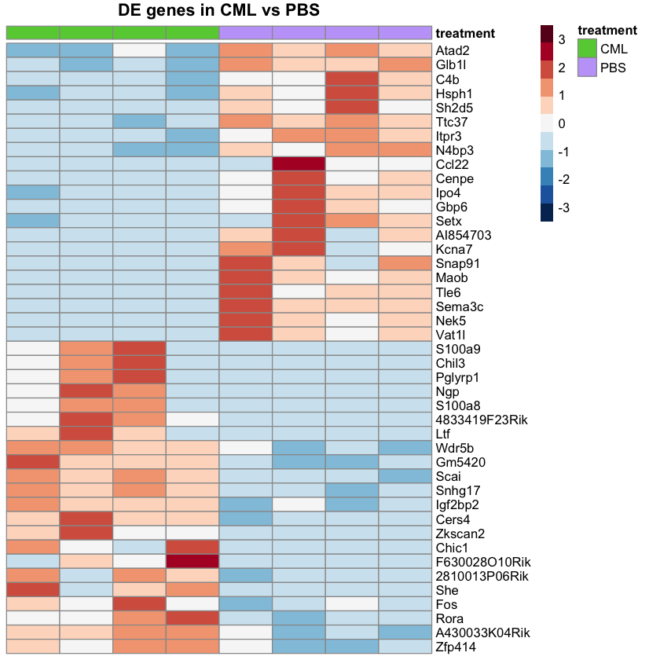

```r
plot_z_score_heatmap(deg1$gene, paste(dir_path, 'z-score-cml-pbs-deg-high-fc.pdf', sep=''))
```

DEGs for CML vs PBS (abs(FC) > 0.58)

```r
deg2$gene
```

1. '2810013P06Rik'

2. '4833419F23Rik'

3. 'A430033K04Rik'

4. 'AI854703'

5. 'Alkbh4'

6. 'Atad2'

7. 'Atp7a'

8. 'C4b'

9. 'Ccl22'

10. 'Cenpe'

11. 'Cers4'

12. 'Chic1'

13. 'Chil3'

14. 'Clk1'

15. 'Dcun1d4'

16. 'F630028O10Rik'

17. 'Fos'

18. 'Gbp6'

19. 'Glb1l'

20. 'Gm5420'

21. 'Hsph1'

22. 'Igf2bp2'

23. 'Ipo4'

24. 'Itpr3'

25. 'Kcna7'

26. 'Ltf'

27. 'Maob'

28. 'N4bp3'

29. 'Nek5'

30. 'Ngp'

31. 'Npnt'

32. 'Pacs2'

33. 'Pglyrp1'

34. 'Rora'

35. 'S100a8'

36. 'S100a9'

37. 'Scai'

38. 'Sema3c'

39. 'Setx'

40. 'Sh2d5'

41. 'She'

42. 'Slc39a8'

43. 'Snap91'

44. 'Snhg17'

45. 'Tbc1d23'

46. 'Tle6'

47. 'Ttc37'

48. 'Unk'

49. 'Usp7'

50. 'Vat1l'

51. 'Wdr5b'

52. 'Xpo1'

53. 'Xpo7'

54. 'Zfp414'

55. 'Zkscan2'

**pdf:** 2

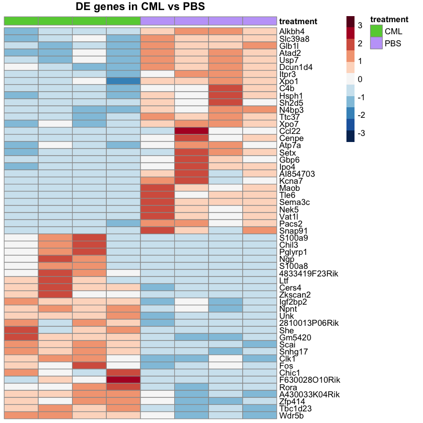

```r
plot_z_score_heatmap(deg2$gene, paste(dir_path, 'z-score-cml-pbs-deg-low-fc.pdf', sep=''))
```

## in non CML / PBS samples

```r
load(paste(dp, "filtered_z_scores.RData", sep=''))
load(paste(dp, "col_order.RData", sep=''))
load(paste(dp, "annot_col.RData", sep=''))
load(paste(dp, "annot_colors.RData", sep=''))
```

```r
annot = annot_col$msa %>%
    rownames_to_column('sample') %>%
    filter(Age == 'Old' ) %>%
    select(-Age)
order = col_order$msa[col_order$msa %in% annot$sample]
samples = annot$sample
annot = annot %>% select(-sample) %>% as.data.frame
rownames(annot) = samples
```

DEGs for CML vs PBS (abs(FC) > 1.5)

```r
deg1$gene
```

1. '2810013P06Rik'

2. '4833419F23Rik'

3. 'A430033K04Rik'

4. 'AI854703'

5. 'Atad2'

6. 'C4b'

7. 'Ccl22'

8. 'Cenpe'

9. 'Cers4'

10. 'Chic1'

11. 'Chil3'

12. 'F630028O10Rik'

13. 'Fos'

14. 'Gbp6'

15. 'Glb1l'

16. 'Gm5420'

17. 'Hsph1'

18. 'Igf2bp2'

19. 'Ipo4'

20. 'Itpr3'

21. 'Kcna7'

22. 'Ltf'

23. 'Maob'

24. 'N4bp3'

25. 'Nek5'

26. 'Ngp'

27. 'Pglyrp1'

28. 'Rora'

29. 'S100a8'

30. 'S100a9'

31. 'Scai'

32. 'Sema3c'

33. 'Setx'

34. 'Sh2d5'

35. 'She'

36. 'Snap91'

37. 'Snhg17'

38. 'Tle6'

39. 'Ttc37'

40. 'Vat1l'

41. 'Wdr5b'

42. 'Zfp414'

43. 'Zkscan2'

**pdf:** 2

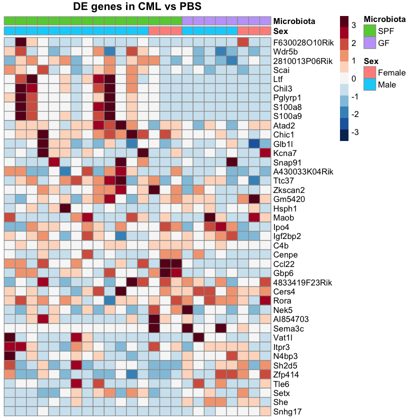

```r
plot_z_score_heatmap(deg1$gene, paste(dir_path, 'z-score-deg-high-fc.pdf', sep=''))
```

DEGs for CML vs PBS (abs(FC) > 0.58)

**pdf:** 2

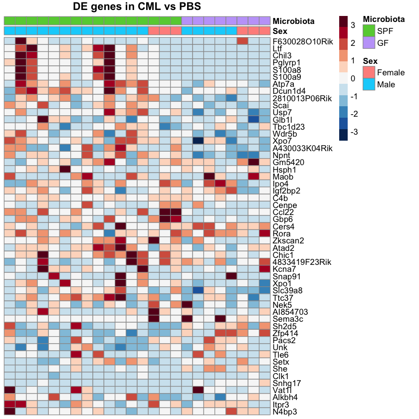

```r
plot_z_score_heatmap(deg2$gene, paste(dir_path, 'z-score-deg-low-fc.pdf', sep=''))
```

DEGs for CML vs PBS from Omar's analysis

**pdf:** 2

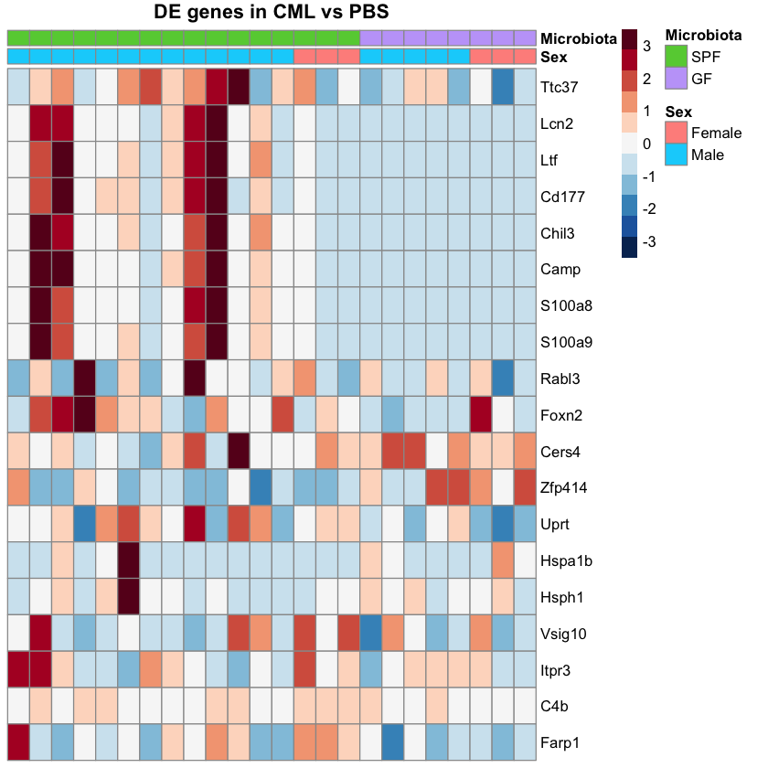

```r
plot_z_score_heatmap(cml_pbs_deg$Gene, paste(dir_path, 'z-score-deg-omar.pdf', sep=''))
```

# Volcano plots for SPF vs GF highlighting DEG in CML vs PBS

```r
load(paste(dp, "3-analyze_microbiota_effect_given_ages_sexes/deg_results.RData", sep=''))
```

```r
sign_fc = 1.5
sign_adj_pvalue = 0.05
```

```r
colors = setNames(c("cornflowerblue","grey","firebrick"),c('Down', 'Non significant', 'Up'))

get_cmp_data = function(comp, deg_results, cml_pbs_deg) {
    deg_res = deg_results[[comp]] %>%
        filter(!is.na(sign_padj_and_fc)) %>%
        mutate(log2FoldChange=-log2FoldChange) %>%
        mutate(Expression=ifelse(
            sign_padj_and_fc & log2FoldChange >= log2(sign_fc),
            'Up',
            ifelse(
                sign_padj_and_fc & log2FoldChange <= -log2(sign_fc),
                'Down',
                'Non significant'))) %>%
        mutate(labels=ifelse(genes %in% cml_pbs_deg & Expression != 'Non significant', genes, "")) %>%
        select(genes, log2FoldChange, pvalue, Expression, labels)
    return(deg_res)
}

plot_volcanoplots = function(deg_res, fp) {
    my_plot = ggplot(data=deg_res, aes(log2FoldChange,-log10(pvalue))) +
        geom_point(aes(col=Expression),
            size=3) +
        scale_colour_manual(values=colors) +
        scale_fill_manual(values=colours) +
        theme(panel.grid.major=element_blank(),
            panel.grid.minor= element_blank(),
            panel.background=element_blank(),
            axis.line=element_line(colour = "black"),
            legend.key=element_blank(),
            text = element_text(size = 15)) +
        xlab("log2(Fold Change)") +
        ylab("-log10(P-Value)") +
        geom_text_repel(aes(label=labels, col=Expression),
            min.segment.length=0,
            box.padding=0.4,
            #point.padding=0.4,
            show.legend=FALSE,
            size=4.5) +
        xlim(xlim[1], xlim[2]) +
        ylim(ylim[1], ylim[2])
    ggsave(fp, plot=my_plot)
    plot(my_plot)
}
```

## Highlighting DEGs for CML vs PBS (abs(FC) > 1.5)

```r
xlim = c(-10,50)
ylim = c(0,300)
```

SPF vs GF (Male, Old)

```
Warning message:
“Removed 28 rows containing missing values (geom_point).”
Warning message:
“Removed 28 rows containing missing values (geom_text_repel).”
Warning message:
“Removed 28 rows containing missing values (geom_point).”
Warning message:
“Removed 28 rows containing missing values (geom_text_repel).”
```

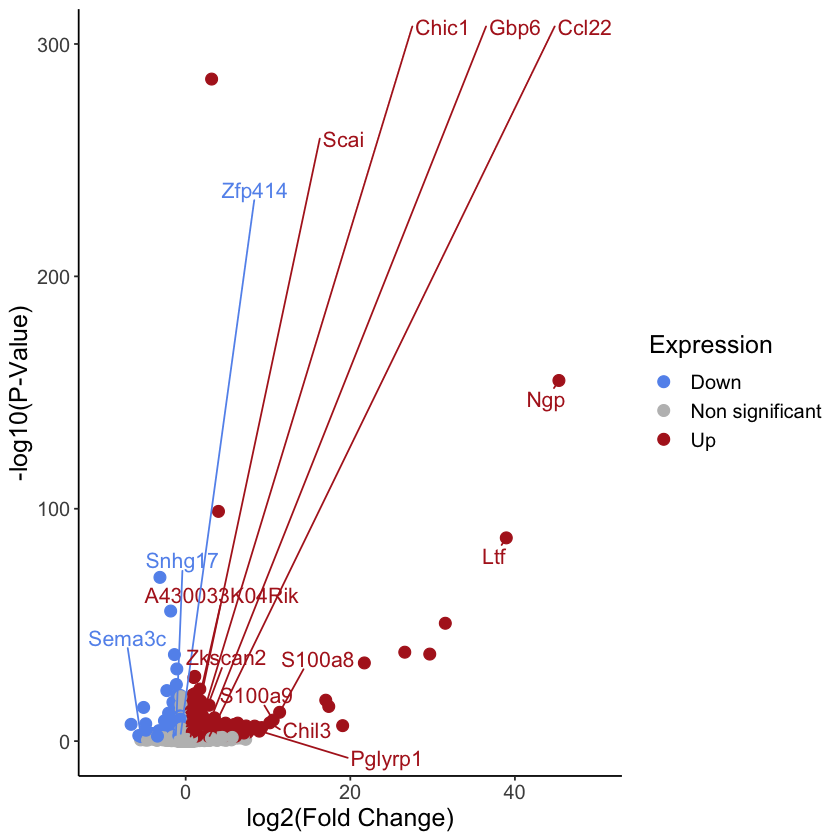

```r
comp = 'GF vs SPF (Male, Old)'
deg_res = get_cmp_data(comp, deg_results, deg1$gene)
plot_volcanoplots(deg_res, paste(dir_path, 'volcanoplot-spf-gf-male-old-high-fc.pdf', sep=''))
```

SPF vs GF (Female, Old)

```
Warning message:
“Removed 17 rows containing missing values (geom_point).”
Warning message:
“Removed 17 rows containing missing values (geom_text_repel).”
Warning message:
“Removed 17 rows containing missing values (geom_point).”
Warning message:
“Removed 17 rows containing missing values (geom_text_repel).”
```

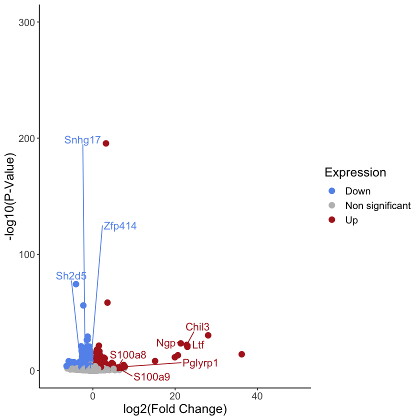

```r
comp = 'GF vs SPF (Female, Old)'
deg_res = get_cmp_data(comp, deg_results, deg1$gene)
plot_volcanoplots(deg_res, paste(dir_path, 'volcanoplot-spf-gf-female-old-high-fc.pdf', sep=''))
```

## Highlighting DEGs for CML vs PBS (abs(FC) > 0.58)

```r
xlim = c(-10,50)
ylim = c(0,300)
```

SPF vs GF (Male, Old)

```
Warning message:
“Removed 28 rows containing missing values (geom_point).”
Warning message:
“Removed 28 rows containing missing values (geom_text_repel).”
Warning message:
“Removed 28 rows containing missing values (geom_point).”
Warning message:
“Removed 28 rows containing missing values (geom_text_repel).”
```

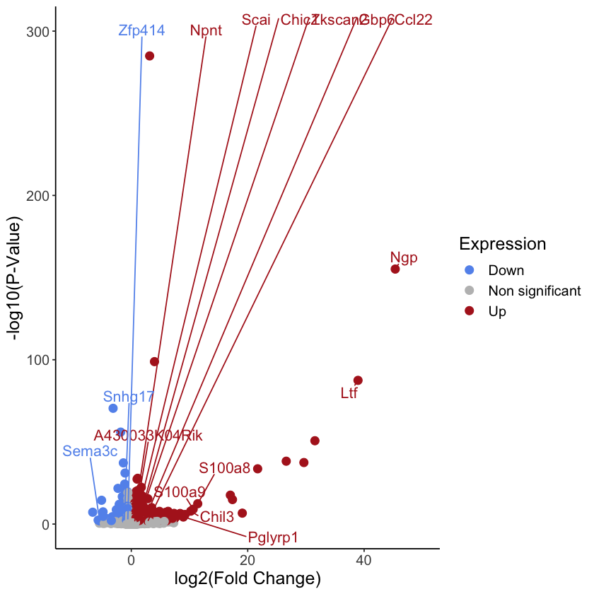

```r
comp = 'GF vs SPF (Male, Old)'
deg_res = get_cmp_data(comp, deg_results, deg2$gene)
plot_volcanoplots(deg_res, paste(dir_path, 'volcanoplot-spf-gf-male-old-low-fc.pdf', sep=''))
```

GF vs SPF (Female, Old)

```
Warning message:
“Removed 17 rows containing missing values (geom_point).”
Warning message:
“Removed 17 rows containing missing values (geom_text_repel).”
Warning message:
“Removed 17 rows containing missing values (geom_point).”
Warning message:
“Removed 17 rows containing missing values (geom_text_repel).”
```

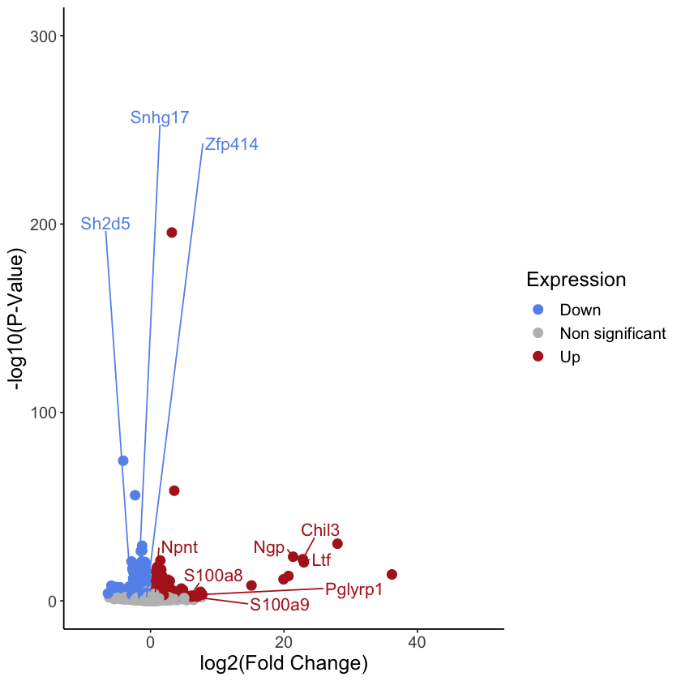

```r
comp = 'GF vs SPF (Female, Old)'
deg_res = get_cmp_data(comp, deg_results, deg2$gene)
plot_volcanoplots(deg_res, paste(dir_path, 'volcanoplot-spf-gf-female-old-low-fc.pdf', sep=''))
```

## Highlighting DEGs for CML vs PBS from Omar's analysis

```r
xlim = c(-10,50)
ylim = c(0,300)
```

GF vs SPF (Male, Old)

```
Warning message:
“Removed 28 rows containing missing values (geom_point).”
Warning message:
“Removed 28 rows containing missing values (geom_text_repel).”
Warning message:
“Removed 28 rows containing missing values (geom_point).”
Warning message:
“Removed 28 rows containing missing values (geom_text_repel).”
```

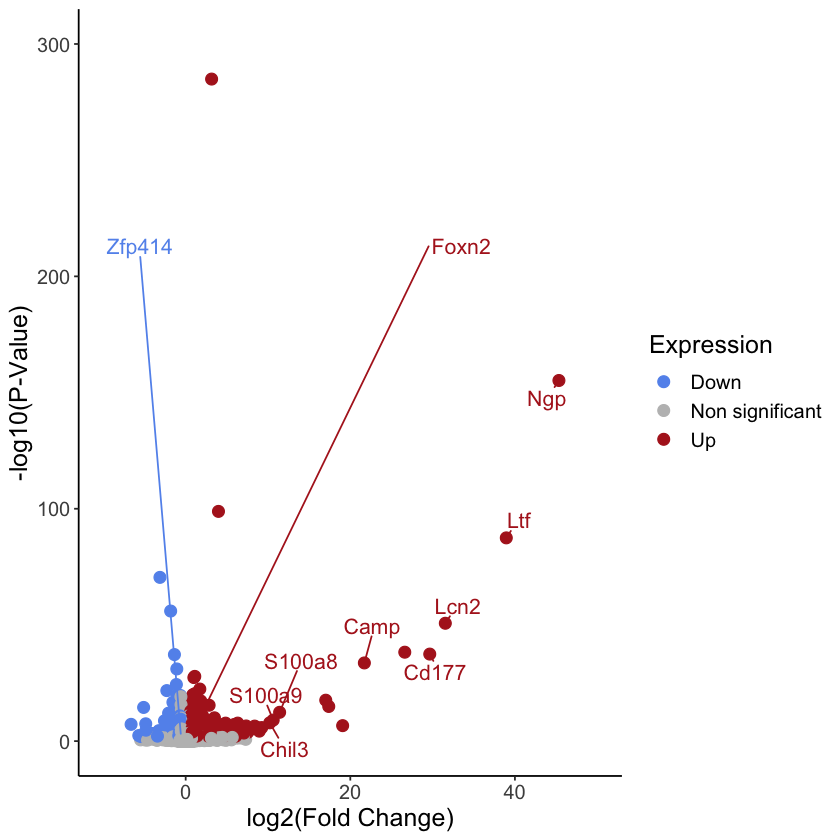

```r
comp = 'GF vs SPF (Male, Old)'
deg_res = get_cmp_data(comp, deg_results, cml_pbs_deg$Gene)
plot_volcanoplots(deg_res, paste(dir_path, 'volcanoplot-spf-gf-male-old-omar.pdf', sep=''))
```

GF vs SPF (Female, Old)

```
Warning message:
“Removed 17 rows containing missing values (geom_point).”
Warning message:
“Removed 17 rows containing missing values (geom_text_repel).”
Warning message:
“Removed 17 rows containing missing values (geom_point).”
Warning message:
“Removed 17 rows containing missing values (geom_text_repel).”
```

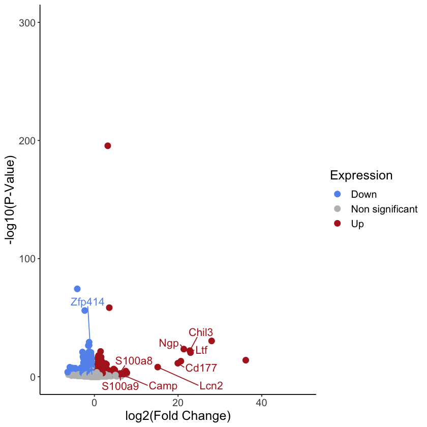

```r
comp = 'GF vs SPF (Female, Old)'
deg_res = get_cmp_data(comp, deg_results, cml_pbs_deg$Gene)
plot_volcanoplots(deg_res, paste(dir_path, 'volcanoplot-spf-gf-male-old-omar.pdf', sep=''))
```

# Citations

```r
citation("rentrez")
```

```
  Winter, D. J. (2017) rentrez: an R package for the NCBI eUtils API
  The R Journal 9(2):520-526

A BibTeX entry for LaTeX users is

  @Article{,
    title = {{rentrez}: an R package for the NCBI eUtils API},
    author = {David J. Winter},
    journal = {The R Journal},
    year = {2017},
    volume = {9},
    issue = {2},
    pages = {520--526},
  }
```

```r
citation("DESeq2")
```

```
  Love, M.I., Huber, W., Anders, S. Moderated estimation of fold change
  and dispersion for RNA-seq data with DESeq2 Genome Biology 15(12):550
  (2014)

A BibTeX entry for LaTeX users is

  @Article{,
    title = {Moderated estimation of fold change and dispersion for RNA-seq data with DESeq2},
    author = {Michael I. Love and Wolfgang Huber and Simon Anders},
    year = {2014},
    journal = {Genome Biology},
    doi = {10.1186/s13059-014-0550-8},
    volume = {15},
    issue = {12},
    pages = {550},
  }
```